# 5-Naive Bayes

# Naive Bayes

This code illustrates the Naive Bayes Model.

We will use the e1070 package.

```r
library(caret)
library(ISLR)
# install.packages("e1071") #install first
library(e1071)
summary(Default)
```

```
 default    student       balance           income
 No :9667   No :7056   Min.   :   0.0   Min.   :  772
 Yes: 333   Yes:2944   1st Qu.: 481.7   1st Qu.:21340
                       Median : 823.6   Median :34553
                       Mean   : 835.4   Mean   :33517
                       3rd Qu.:1166.3   3rd Qu.:43808
                       Max.   :2654.3   Max.   :73554
```

Clean the data, and divide into training and test

```r
#remove student status, which is the second variable
MyData<-Default[,-2]
set.seed(123)
#Divide data into test and train
Index_Train<-createDataPartition(MyData$default, p=0.8, list=FALSE)
Train <-MyData[Index_Train,]
Test  <-MyData[-Index_Train,]
```

Now, run the Naive Bayes model, and predict Default status on the test set

```r
# Build a naïve Bayes classifier
nb_model <-naiveBayes(default~balance+income,data = Train)
nb_model
```

```
Naive Bayes Classifier for Discrete Predictors

Call:
naiveBayes.default(x = X, y = Y, laplace = laplace)

A-priori probabilities:
Y
        No        Yes
0.96662917 0.03337083

Conditional probabilities:
     balance
Y         [,1]     [,2]
  No   802.794 456.9656
  Yes 1756.455 340.4341

     income
Y         [,1]     [,2]
  No  33532.92 13351.73
  Yes 31311.38 13515.08
```

The first part of the output above shows the ratios of default (yes) and default (no) in the training set (called a priori probabilities), followed by a table giving for each target class, mean and standard deviation of the (sub-)variable. Also, note that the Naive Bayes algorithm assumes a Normal distribution for the independent variables, as we discussed regarding the use of numeric predictors. If the independent variables had been categorical, then you would see the conditional probabilities p(X|Y) for each attribute level given the default status.

Now, use the model on the test set

```r
# Predict the default status of test dataset
Predicted_Test_labels <-predict(nb_model,Test)
library("gmodels")
# Show the confusion matrix of the classifier
CrossTable(x=Test$default,y=Predicted_Test_labels, prop.chisq = FALSE)
```

```
   Cell Contents
|-------------------------|
|                       N |
|           N / Row Total |
|           N / Col Total |
|         N / Table Total |
|-------------------------|


Total Observations in Table:  1999


             | Predicted_Test_labels
Test$default |        No |       Yes | Row Total |
-------------|-----------|-----------|-----------|
          No |      1928 |         5 |      1933 |
             |     0.997 |     0.003 |     0.967 |
             |     0.975 |     0.238 |           |
             |     0.964 |     0.003 |           |
-------------|-----------|-----------|-----------|
         Yes |        50 |        16 |        66 |
             |     0.758 |     0.242 |     0.033 |
             |     0.025 |     0.762 |           |
             |     0.025 |     0.008 |           |
-------------|-----------|-----------|-----------|
Column Total |      1978 |        21 |      1999 |
             |     0.989 |     0.011 |           |
-------------|-----------|-----------|-----------|
```

Our results indicate that we misclassified a total of 55 cases. 5 as False Positives, and 50 as False Negatives.

It is sometimes useful to output the raw prediction probabilities rather than the predicted class. To do that, we use the raw option in the model.

```r
nb_model <- naiveBayes(default~balance+income,data = Train)
#Make predictions and return probability of each class
Predicted_Test_labels <-predict(nb_model,Test, type = "raw")
#show the first few values
head(Predicted_Test_labels)
```

```
            No          Yes
[1,] 0.9999207 7.933836e-05
[2,] 0.9745238 2.547624e-02
[3,] 0.9999951 4.907314e-06
[4,] 0.9998550 1.449972e-04
[5,] 0.9893221 1.067789e-02
[6,] 0.9999997 2.913091e-07
```

## ROC Curves

We can now output the ROC curves. Remember that ROC curves plot sensitivity (true positive rate) versus (1 - specificity), which is (1 - TNR) or false positive rate. See [here](https://en.wikipedia.org/wiki/Receiver_operating_characteristic) for more details

```r
# install.packages("pROC") # install if necessary
library(pROC)
#Passing the second column of the predicted probabilities
#That column contains the probability associate to ‘yes’
roc(Test$default, Predicted_Test_labels[,2])
```

```
Call:
roc.default(response = Test$default, predictor = Predicted_Test_labels[,     2])

Data: Predicted_Test_labels[, 2] in 1933 controls (Test$default No) < 66 cases (Test$default Yes).
Area under the curve: 0.9395
```

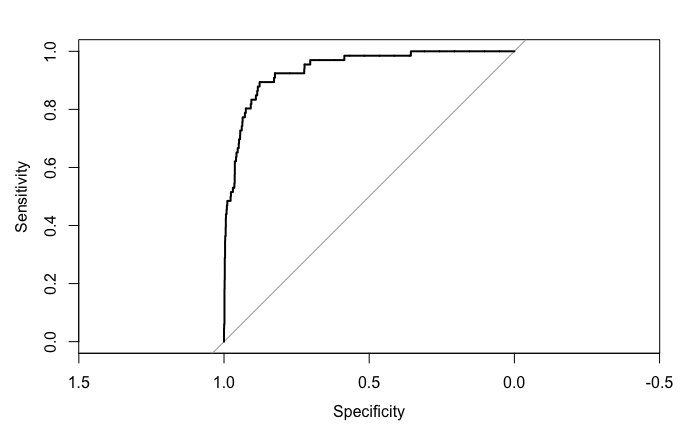

```r
plot.roc(Test$default,Predicted_Test_labels[,2])
```

The AUC is 0.9395. The ROC curve is also plotted, though note that the X-Axis is Specificity (True Negative Rate), rather than 1-Specificity (False Positive Rate). This function can also be thought of as a plot of the power as a function of the Type I Error of the decision rule.

# Box-Cox Transformation

We first illustrate the transformation of data using the Box-Cox transformation approach

```r
library(ISLR)
library(caret)
#Create a Box-Cox Transformation Model
Box_Cox_Transform<-preProcess(Default,method = "BoxCox")
Box_Cox_Transform
```

```
Created from 10000 samples and 3 variables

Pre-processing:
  - Box-Cox transformation (1)
  - ignored (2)

Lambda estimates for Box-Cox transformation:
0.7
```

Now, we apply the transformation

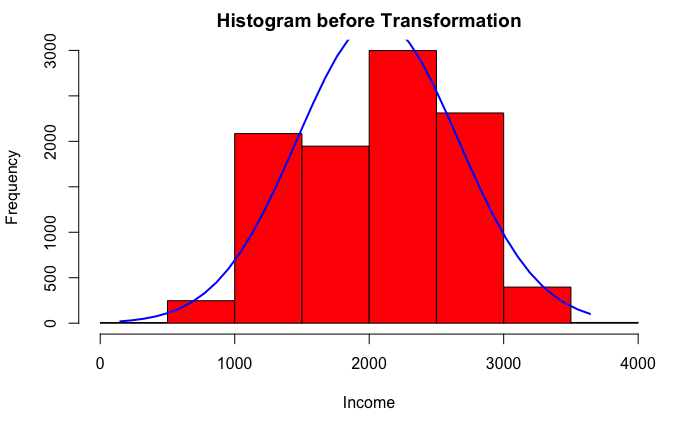

```r
Default_Transformed=predict(Box_Cox_Transform,Default)
y <- Default_Transformed$income
h<-hist(y, breaks=10, col="red", xlab="Income",
   main="Histogram before Transformation")
xfit<-seq(min(y),max(y),length=40)
yfit<-dnorm(xfit,mean=mean(y),sd=sd(y))
yfit <- yfit*diff(h$mids[1:2])*length(y)
lines(xfit, yfit, col="blue", lwd=2)
```

## Hypertuning

```r
library(caret)
library(ISLR)
#remove student status, which is the second variable
MyData<-Default[,-2]
set.seed(123)
#Divide data into test and train
Index_Train<-createDataPartition(MyData$default, p=0.8, list=FALSE)
Train <-MyData[Index_Train,]
Test  <-MyData[-Index_Train,]
nb_model <-train(default~balance+income,data = Train, preProc = c("BoxCox", "center", "scale"))
# Predict the default status of test dataset
Predicted_Test_labels <-predict(nb_model,Test)
library("gmodels")
# Show the confusion matrix of the classifier
CrossTable(x=Test$default,y=Predicted_Test_labels, prop.chisq = FALSE)
```

```
   Cell Contents
|-------------------------|
|                       N |
|           N / Row Total |
|           N / Col Total |
|         N / Table Total |
|-------------------------|


Total Observations in Table:  1999


             | Predicted_Test_labels
Test$default |        No |       Yes | Row Total |
-------------|-----------|-----------|-----------|
          No |      1921 |        12 |      1933 |
             |     0.994 |     0.006 |     0.967 |
             |     0.976 |     0.387 |           |
             |     0.961 |     0.006 |           |
-------------|-----------|-----------|-----------|
         Yes |        47 |        19 |        66 |
             |     0.712 |     0.288 |     0.033 |
             |     0.024 |     0.613 |           |
             |     0.024 |     0.010 |           |
-------------|-----------|-----------|-----------|
Column Total |      1968 |        31 |      1999 |
             |     0.984 |     0.016 |           |
-------------|-----------|-----------|-----------|
```